## This is an email preview for RStudio Connect

# Diamonds and Real Estate in Dallas

We can include parts from the parent `"connect-example-main.Rmd"` document by adding an empty R Markdown code chunk with a matching name (in this case `diamonds_plot`). This is great because we can reuse parts from the main report document.

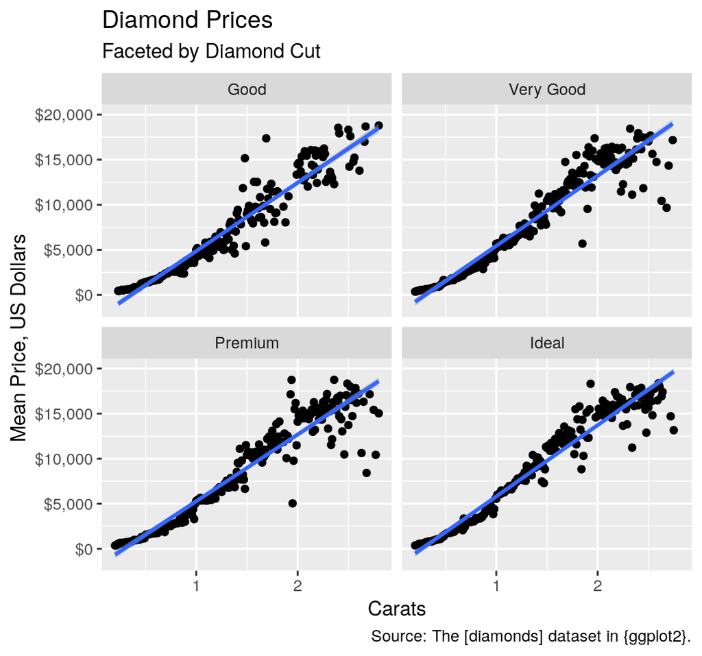

The real estate table (in the parent document’s `dallas_home_sales` chunk) can be included in the same way:

```
## # A tibble: 16 x 2
##     year total_sales
##    <int>       <dbl>
##  1  2000       45446
##  2  2001       46992
##  3  2002       47199
##  4  2003       49278
##  5  2004       54514
##  6  2005       59980
##  7  2006       64226
##  8  2007       59695
##  9  2008       50848
## 10  2009       45891
## 11  2010       42383
## 12  2011       42656
## 13  2012       50411
## 14  2013       59714
## 15  2014       60154
## 16  2015       36735
```

The `dallas_home_sales` object (from the namesake **R** code chunk) is also available and can be further processed to generate different output just for the email document.

```
## # A tibble: 5 x 2
##    year total_sales
##   <int>       <dbl>
## 1  2011       42656
## 2  2012       50411
## 3  2013       59714
## 4  2014       60154
## 5  2015       36735
```

This message was generated at Wednesday, May 6, 2020 at 8:13 PM (UTC).

This Version: https://connect.example.com/content/1234/_rev5678  
Latest Version: https://connect.example.com/content/1234/